# ECO634- Lab 6

Mercy Melo

```r
require(palmerpenguins)
```

# Question 1

Copy your code chunk for your SSE function

```r
rm(list = ls())

sse_mean = function(x)
  {
  sd(x, na.rm=TRUE) / sqrt(sum(!is.na(x)))
}

sse_mean(penguins$body_mass_g)
```

```
## [1] 43.36473
```

```r
sse_mean(mtcars$mpg)
```

```
## [1] 1.065424
```

# Question 2

Copy your code chunk for your two_group_resample function

```r
two_group_resample = function(x, n_1, n_2)
{
  dat_1 = sample(x, n_1, replace = TRUE)
  dat_2 = sample(x, n_2, replace = TRUE)

  difference_in_means =
    mean(dat_1, na.rm = TRUE) - mean(dat_2, na.rm = TRUE)

  return(difference_in_means)
}
```

# Question 3

Does your function perform Monte Carlo or bootstrap resampling, i.e. does it simulate a null or an alternative hypothesis?

This function performs Monte Carlo resampling. It uses the flipper lengths of all species to produce the resampled values, rather than using each species’ flipper length values separately to produce dat_1 from one species’ data and dat_2 from the other species’s data. To perform bootstrap resampling, you would use a function like this:

```r
two_group_resample2 = function(x, y, n_1, n_2)
{
  dat_1 = sample(x, n_1, replace = TRUE)
  dat_2 = sample(y, n_2, replace = TRUE)

  difference_in_means =
    mean(dat_1, na.rm = TRUE) - mean(dat_2, na.rm = TRUE)

  return(difference_in_means)
}

adelie <- subset(penguins, species == "Adelie")
chinstrap <- subset(penguins, species == "Chinstrap")

two_group_resample2(adelie$flipper_length_mm, chinstrap$flipper_length_mm, 57, 109)
```

```
## [1] -5.232738
```

# Question 4

Create histogram of the resampled differences of means

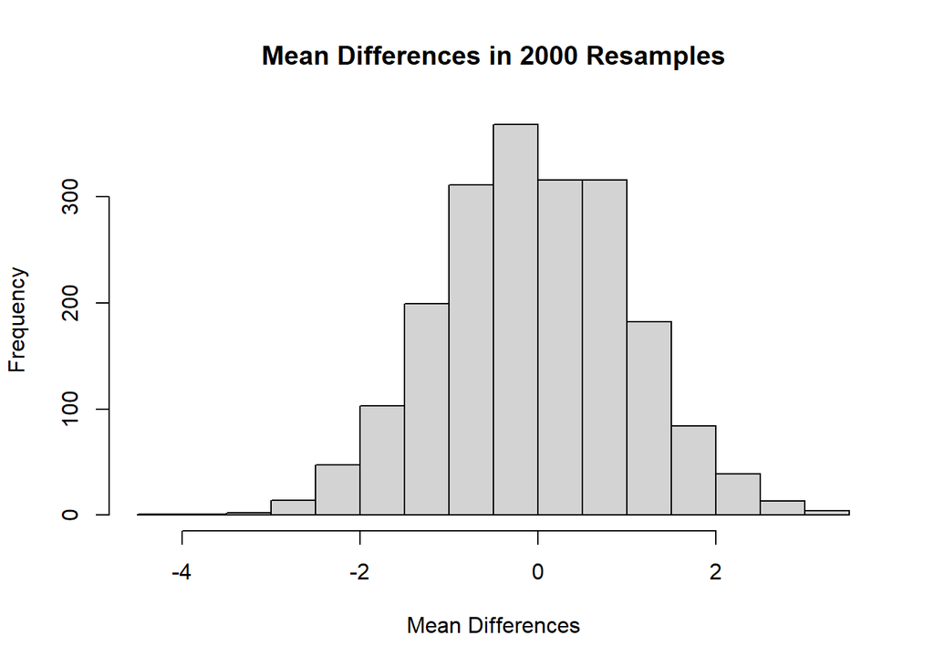

# Question 5

How many of your resampled differences of means were greater than 5.8? Include code used to find this value.

None of my resampled mean differences were greater than 5.8. Since the t-test displayed a p-value of 6.05e-08 (less than 0.0001), we can predict that a mean difference of 5.8 or larger would be seen fewer than 1 out of 10000 times. Since we only resampled 2000 times, we wouldn’t expect to find a difference in means of 5.8 or larger.

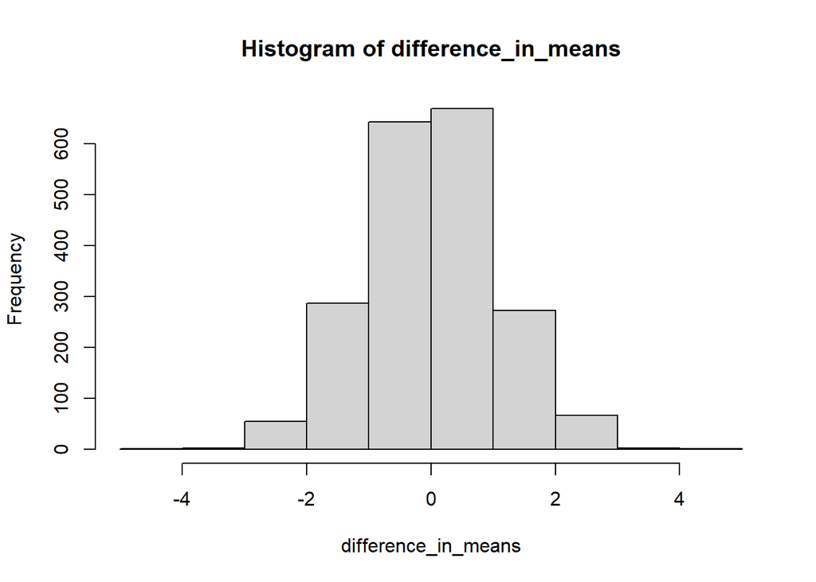

```r
n = 2000
difference_in_means = c()
for (i in 1:n)
{
  difference_in_means = c(
    difference_in_means,
    two_group_resample(dat_pen$flipper_length_mm, 68, 152)
  )
}
hist(difference_in_means)
```

```r
t_test = t.test(dat_pen$flipper_length_mm ~ dat_pen$species)
t_test
```

```
##
##  Welch Two Sample t-test
##
## data:  dat_pen$flipper_length_mm by dat_pen$species
## t = -5.7804, df = 119.68, p-value = 6.049e-08
## alternative hypothesis: true difference in means is not equal to 0
## 95 percent confidence interval:
##  -7.880530 -3.859244
## sample estimates:
##    mean in group Adelie mean in group Chinstrap
##                189.9536                195.8235
```

```r
diff_observed = round(diff(t_test$estimate), digits = 3)
print(diff_observed, digits = 3)
```

```
## mean in group Chinstrap
##                    5.87
```

```r
sum(abs(difference_in_means) >= diff_observed)
```

```
## [1] 0
```

# Question 6

Given a p value of less than 1 per 10 million, how many simulations do you think you would have to do to see a difference in mean flipper length equal to or greater than 5.8 mm?

You would have to run at least 10 million simulations to have a good chance of seeing a mean difference of 5.8 or larger. Even running the simulation 10 million times would not guarantee that you’d see this difference since the sampling method is based on randomly-generated values.

# Question 7

Include a boxplot of a chosen variable from the penguins dataset.

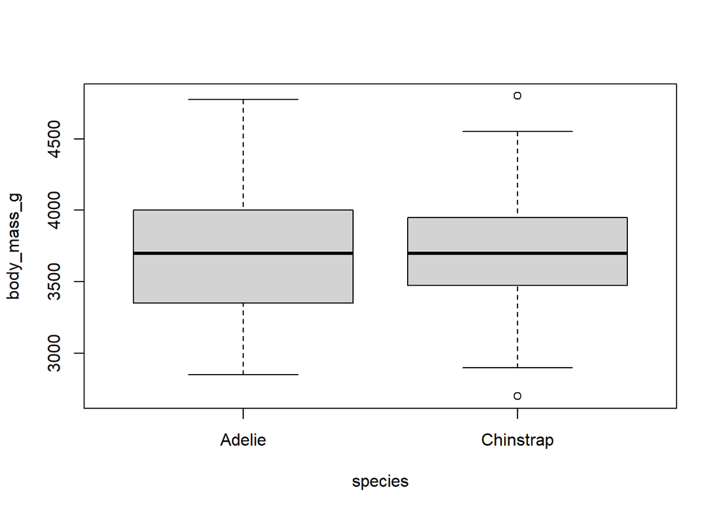

# Question 8

Report the group means and difference between the means.

```r
agg_means = aggregate(
  body_mass_g ~ species,
  data = dat_pen,
  FUN = "mean",
  na.rm = TRUE)
diff_crit = diff(agg_means[, 2])

agg_means
```

```
##     species body_mass_g
## 1    Adelie    3700.662
## 2 Chinstrap    3733.088
```

```r
diff_crit
```

```
## [1] 32.42598
```

# Question 9

# Question 10

How many differences in means were greater than diff_crit?

```r
n = 1000
difference_in_means_mass = c()
for (i in 1:n)
{
  difference_in_means_mass = c(
    difference_in_means_mass,
    two_group_resample(dat_pen$body_mass_g, 68, 152)
  )
}

sum(abs(difference_in_means_mass) >= diff_crit)
```

```
## [1] 635
```

# Question 11

Include a histogram of your simulation results in your report. Make sure it has appropriate title and labels.

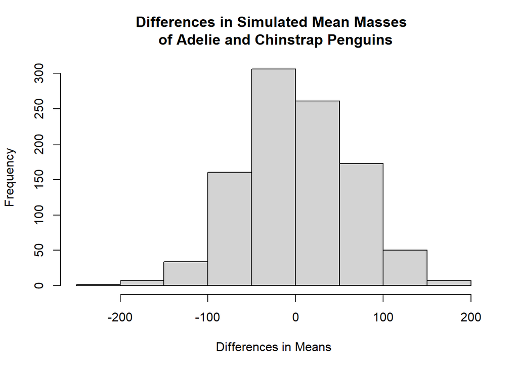